# Data visualization tutorial

### Add color

We can begin to customize our plot by adding color. You can simply change the color of the data points like so. *Note that the tidyverse understands both ‘color’ and ‘colour’.*

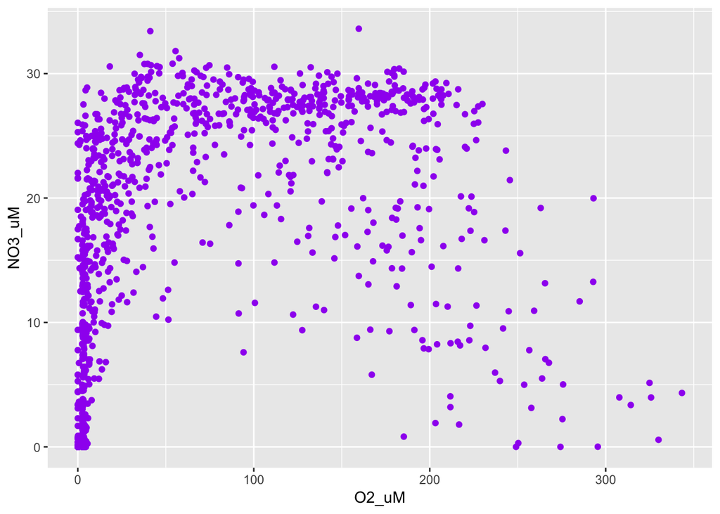

```r
dat %>%
  ggplot(aes(x=O2_uM, y=NO3_uM)) +
  geom_point(color="purple")
```

There are two important things to note here. First, since we are changing the color of the points, we must specify the color within `geom_point`. If we were to instead specify color in the main `ggplot` function, there are no points (yet) to color and it fails.

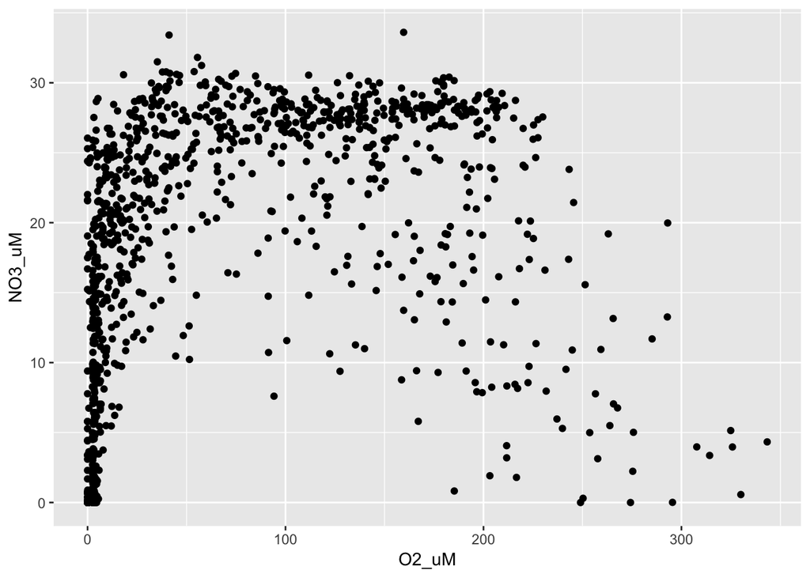

```r
dat %>%
  ggplot(aes(x=O2_uM, y=NO3_uM), color="purple") +
  geom_point()
```

Secondly, color is outside of the `aes` argument because it is not an aesthetic. Aesthetics *must* refer to some variable in the data. So, if we put the world “purple” as a color aesthetic instead, ggplot things that we want to color our data by the group “purple” and will use its default color to do so.

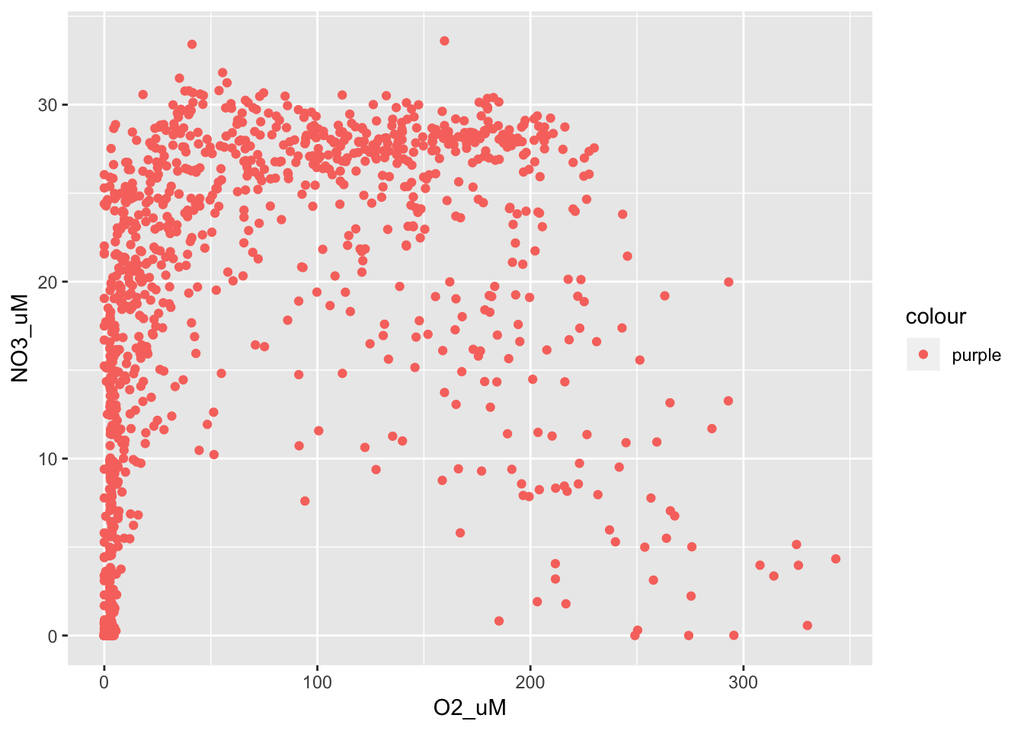

```r
dat %>%
  ggplot(aes(x=O2_uM, y=NO3_uM)) +
  geom_point(aes(color="purple"))
```

### Add shape

Similar to color, we can change the shape of the points. R has a number of shorthand codes for shapes which can be found [here](http://sape.inf.usi.ch/quick-reference/ggplot2/shape).

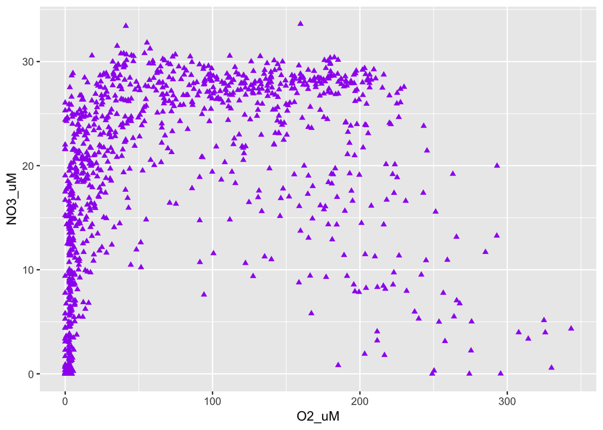

```r
dat %>%
  ggplot(aes(x=O2_uM, y=NO3_uM)) +
  geom_point(color="purple", shape=17)
```

### Mapping variables to color

Thinking back to our motivating question in regards to oxygen, nitrate, and hydrogran sulfide in Saanich, perhaps we can get a better understanding of what is happening if we instead plot all 3 variables of interest on 1 plot.

One way to achieve this is to map the third variable as a color *aesthetic* on a plot of the other 2 variables like so.

As before, we want to place the color in the `geom_point` layer since it is the points that we want to color. However, in contrast to changing all points to a single color, using a variable to color the points is an *aesthetic* because it relies on data from the data set. Thus, color must now be contained within `aes`.

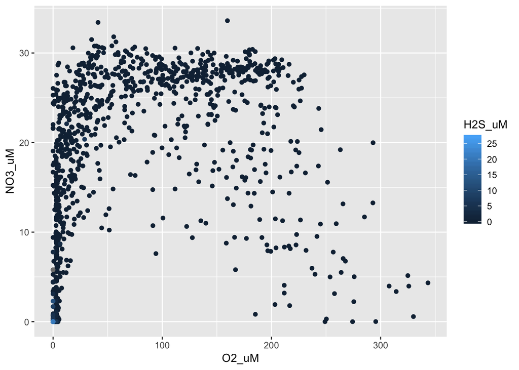

```r
dat %>%
  ggplot(aes(x=O2_uM, y=NO3_uM)) +
  geom_point(aes(color=H2S_uM))
```

However, ggplot plots the observations in the order that they appear in the data frame. Since most of the hydrogen sulfide values are zero, we want to plot the non-zero data *last* so that they are visually on top in the plot.

To do this, we use `arrange` (a `dplyr` verb) by this variable to sort the rows by ascending hydrogen sulfide values. We also remove observations without hydrogen sulfide data (NA) since these will not map to any color. (See the ‘Data manipulation in R’ tutorial to learn more.)

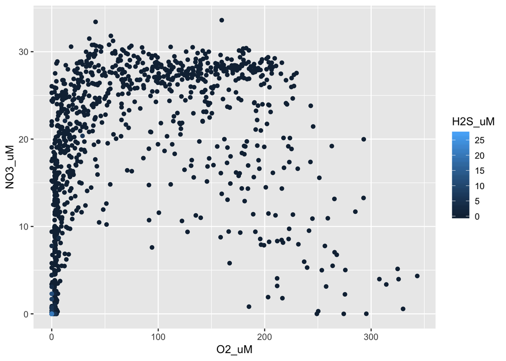

```r
dat %>%
  arrange(H2S_uM) %>%
  filter(!is.na(H2S_uM)) %>%

  ggplot(aes(x=O2_uM, y=NO3_uM)) +
  geom_point(aes(color=H2S_uM))
```

This is a great example of why we use a pipe to input data into `ggplot`. Doing so allows us to manipulate `dat` using other tidyverse functions and then input these modified data directly into a ggplot without saving an intermediate data frame in the R environment.

### Mapping variables to shape

We could also map a third variable to shape. However, this only works for categorical data so mapping to hydrogen sulfide fails.

```r
dat %>%
  arrange(H2S_uM) %>%
  filter(!is.na(H2S_uM)) %>%

  ggplot(aes(x=O2_uM, y=NO3_uM)) +
  geom_point(aes(shape=H2S_uM))
```

```
## Error: A continuous variable can not be mapped to shape
```

So, we need to rethink how we are plotting these data if we want to use shape. One option is to instead plot all 3 variables as shapes along depth. We would do so with the following setup. But what are our x and shape variables?

```r
dat %>%
  ggplot(aes(x=?, y=Depth_m)) +
  geom_point(aes(shape=?))
```

We actually have multiple variables that we want to input for x (oxygen, nitrate, hydrogen sulfide) and no variable to use for the 3 shape groups we want to see. Thus, we need to `gather` our 3 geochemical variables into a single column.

```r
dat %>%
  select(Depth_m, O2_uM, NO3_uM, H2S_uM) %>%
  gather(key="Chemical", value="Concentration", O2_uM, NO3_uM, H2S_uM)
```

```
##   Depth_m Chemical Concentration
## 1      10    O2_uM       225.237
## 2      20    O2_uM       220.985
## 3      40    O2_uM       201.769
## 4      60    O2_uM       197.947
## 5      75    O2_uM       193.762
## 6      85    O2_uM       150.404
```

*More on `gather` in ‘Data manipulation in R’ tutorial*

If we pipe these modified data into our plot, we now have individual variables to use as x and shape.

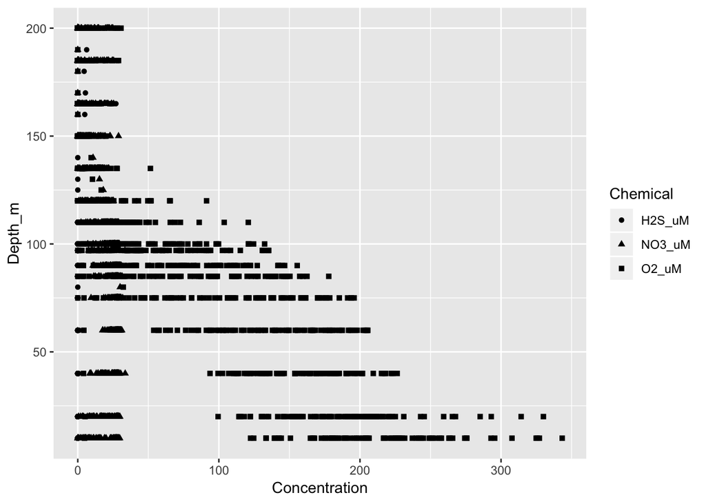

```r
dat %>%
  select(Depth_m, O2_uM, NO3_uM, H2S_uM) %>%
  gather(key="Chemical", value="Concentration", O2_uM, NO3_uM, H2S_uM) %>%

  ggplot(aes(x=Concentration, y=Depth_m)) +
  geom_point(aes(shape=Chemical))
```

We could further customize this plot by reversing the y-axis (since we traditionally think of depth going down) and adding color on top of shape!

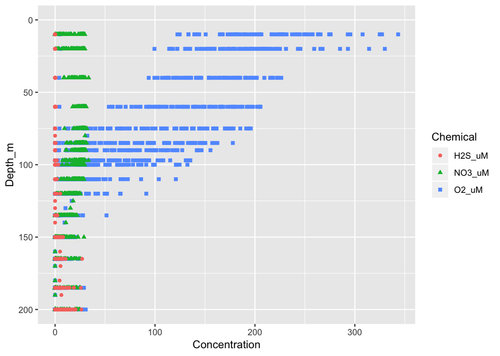

```r
dat %>%
  select(Depth_m, O2_uM, NO3_uM, H2S_uM) %>%
  gather(key="Chemical", value="Concentration", O2_uM, NO3_uM, H2S_uM) %>%

  ggplot(aes(x=Concentration, y=Depth_m)) +
  geom_point(aes(shape=Chemical, color=Chemical)) +
  scale_y_reverse(limits=c(200, 0))
```

## Facets

Rather than putting a lot of information into a single graphic, we can split the graphic into panels by certain features. This is called faceting.

Let’s return to our most recent plot.

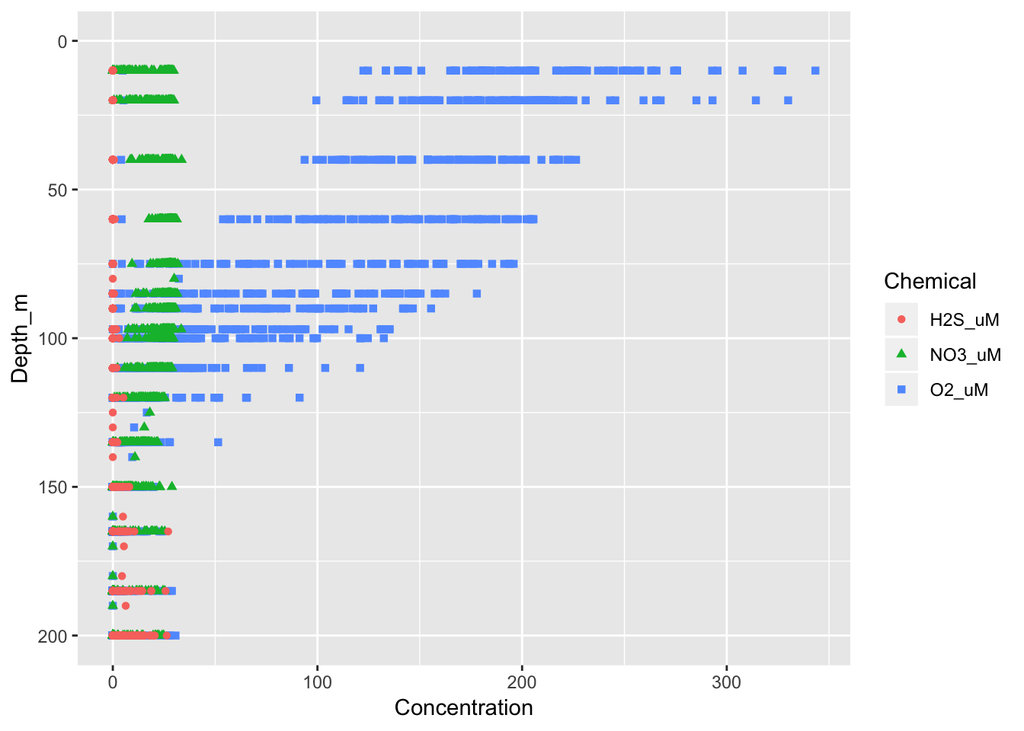

Many of our data points overlap so we may want to separate the geochemical variables into separate plots. Instead of independently creating 3 plots, we can instead add `facet_wrap` of the Chemical variable to the exact same code from above.

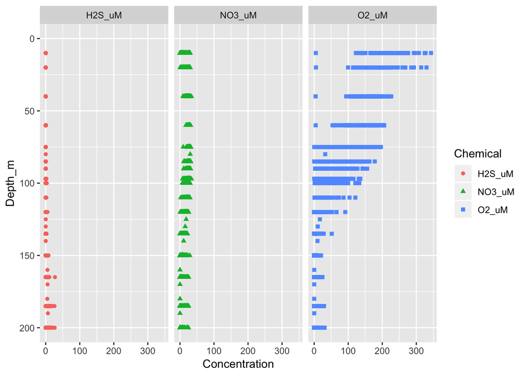

```r
dat %>%
  select(Depth_m, O2_uM, NO3_uM, H2S_uM) %>%
  gather(key="Chemical", value="Concentration", O2_uM, NO3_uM, H2S_uM) %>%

  ggplot(aes(x=Concentration, y=Depth_m)) +
  geom_point(aes(shape=Chemical, color=Chemical)) +
  scale_y_reverse(limits=c(200, 0)) +
  facet_wrap(~Chemical) ## New facets
```

Since the 3 variables are on somewhat different scales, we can also tell ggplot to scale the x-axes independently within each facet with the `scales` option.

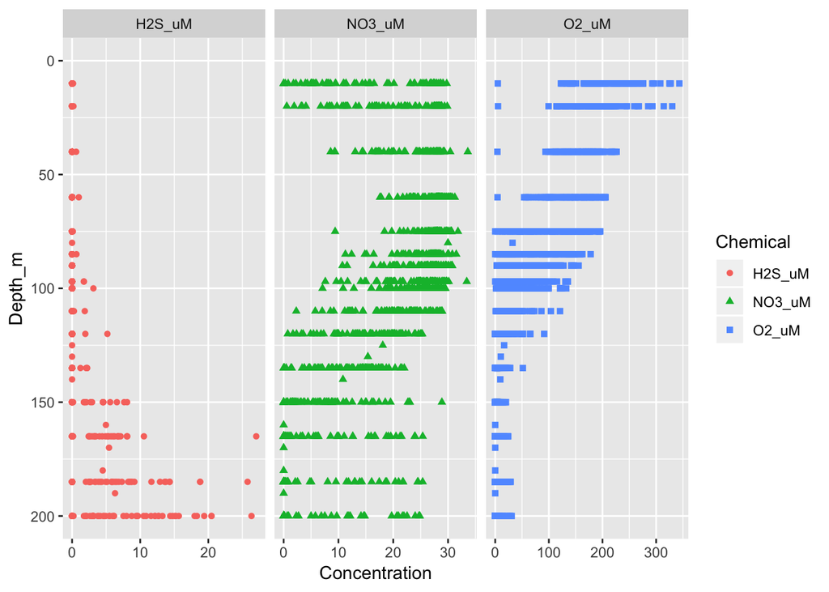

```r
dat %>%
  select(Depth_m, O2_uM, NO3_uM, H2S_uM) %>%
  gather(key="Chemical", value="Concentration", O2_uM, NO3_uM, H2S_uM) %>%

  ggplot(aes(x=Concentration, y=Depth_m)) +
  geom_point(aes(shape=Chemical, color=Chemical)) +
  scale_y_reverse(limits=c(200, 0)) +
  facet_wrap(~Chemical, scales="free_x")
```

You can also facet across multiple variables using `facet_grid`.

## Further customization

ggplot allows you to complete many, many customizations to plots that we do not have time to go over. Some aspects you may want to explore for the next problem set include:

- **Other geoms:** There are many more geoms outside of a scatterplot. Check them out on the [R cheatsheets](https://www.rstudio.com/resources/cheatsheets/) also available in RStudio under Help > Cheatsheets
- **Themes:** By default, ggplot uses a gray color scheme. However, there are a number of other themes that come with ggplot as well as many more in the additional package ggthemes. You can see many examples from [ggplot](https://datascienceplus.com/ggplot2-themes-examples/) or [ggthemes](http://www.rpubs.com/Mentors_Ubiqum/ggthemes_1).
- **Labels:** All aspects of labs can be changed in your plot, including axes, legends, facets, etc. This can be done with `labs()` or in a custom theme with `theme()`
- **Multi-panel figures:** While faceting achieves this for data in a single data frame, you may wish to combine figure from different data sets or different subsets of the same data set. This can be done with a number of packages. We recommend `cowplot` as it easily combines and labels multi-panel figures.
- **Saving plots:** You can simply save you plot in RStudio with the ‘Export’ button in the ‘Plots’ tab. However, for a fully reproducible script, checkout the `ggsave()` function!

*And sometimes after all this, it’s still not perfect. So, don’t feel bad if you need to finalize plots for publication in another editor like Illustrator. Sometimes it’s a necessary evil.*

## Additional resources

- [R cheatsheets](https://www.rstudio.com/resources/cheatsheets/) also available in RStudio under Help > Cheatsheets
- [ggplot tutorial 1](http://r-statistics.co/Complete-Ggplot2-Tutorial-Part1-With-R-Code.html)
- [ggplot tutorial 2](https://rpubs.com/g_jw/ggplot2_tutorial)
- [ggplot tutorial 3](http://tutorials.iq.harvard.edu/R/Rgraphics/Rgraphics.html#the_1_faq) ***